# Prepare stomach content data

Author

Max Lindmark

Published

September 22, 2023

## Load libraries

```r
library(tidyverse)
library(tidylog)
library(janitor)
library(devtools)
library(sdmTMB)

# Import some plotting functions
# Source code for map plots
# You need: # devtools::install_github("seananderson/ggsidekick") # not on CRAN; library(ggsidekick)
devtools::source_url("https://raw.githubusercontent.com/maxlindmark/pred-prey-overlap/main/R/functions/map-plot.R")
options(ggplot2.continuous.colour = "viridis")

# Set path
home <- here::here()
```

## Read data

I downloaded stomach data from the Baltic, all countries, from year 1993-now, on the morning of Sep 22nd. I see lots of new and old data missing. Here’s a test script to prepare those data. Text in red are warnings/questions from me.

In our case study, we want to create a response variable that is the weight ratio of saduria, herring and sprat (separately) to cod weight. Hence we need, per predator, the total weight of these species, and if they are absent, weight should be 0. We also need coordinates for these stomachs. To get there, we need to do the follow:

1. Join all data sets
2. Filter predators with the above prey present and calculate the total weight of these for each predator
3. Filter predators where these prey are not present.
4. Bind rows, and replace NA with 0

```r
fi <- read_csv(paste0(home, "/data/stomach/StomachContent_0922544684/File_information.csv"))
hi <- read_csv(paste0(home, "/data/stomach/StomachContent_0922544684/HaulInformation.csv"))
pred <- read_csv(paste0(home, "/data/stomach/StomachContent_0922544684/PredatorInformation.csv"))
prey <- read_csv(paste0(home, "/data/stomach/StomachContent_0922544684/PreyInformation.csv"))
```

Have a look at the data… The description of the data can be found here: http://datsu.ices.dk/web/selRep.aspx?Dataset=157

```r
names(fi)
```

```
[1] "tblUploadID"            "Country"                "Reporting_organisation"
[4] "CruiseID"
```

```r
names(hi)
```

```
 [1] "tblUploadID"   "tblHaulID"     "Ship"          "Gear"
 [5] "HaulNo"        "StationNumber" "Year"          "Month"
 [9] "Day"           "Time"          "ShootLat"      "ShootLong"
[13] "HaulLat"       "HaulLong"      "ICESrectangle" "Depth"
[17] "Survey"        "ICESDatabase"  "Notes"
```

```r
names(pred)
```

```
 [1] "tblUploadID"              "tblHaulID"
 [3] "tblPredatorInformationID" "Ship"
 [5] "Gear"                     "HaulNo"
 [7] "StationNumber"            "Year"
 [9] "Month"                    "Day"
[11] "Time"                     "FishID"
[13] "AphiaIDPredator"          "IndWgt"
[15] "Number"                   "MeasurementIncrement"
[17] "Length"                   "Code"
[19] "Age"                      "Sex"
[21] "MaturityScale"            "MaturityStage"
[23] "PreservationMethod"       "Regurgitated"
[25] "StomachFullness"          "FullStomWgt"
[27] "EmptyStomWgt"             "StomachEmpty"
[29] "GenSamp"                  "Notes"
```

```r
names(prey)
```

```
 [1] "tblUploadID"              "tblHaulID"
 [3] "tblPredatorInformationID" "tblPreyInformationID"
 [5] "Ship"                     "Gear"
 [7] "HaulNo"                   "StationNumber"
 [9] "Year"                     "Month"
[11] "Day"                      "Time"
[13] "FishID"                   "AphiaIDPredator"
[15] "AphiaIDPrey"              "IdentMet"
[17] "DigestionStage"           "GravMethod"
[19] "SubFactor"                "PreySequence"
[21] "Count"                    "UnitWgt"
[23] "Weight"                   "UnitLngt"
[25] "Length"                   "OtherItems"
[27] "OtherCount"               "OtherWgt"
[29] "AnalysingOrg"             "Notes"
```

## Join all data files

We do this specific order: fi -> hi -> pred -> prey.

For some joins, there are multiple column names shared in addition to the key. I suppose I could remove them and keep only the ID key and the non-shared columns, but in I could also keep them. First I need to ensure they are the same, and not only have the same name though. Will also check if both datasets have the same amount of NA before choosing which column to carry from which dataset.

```r
hi <- left_join(hi, fi, by = "tblUploadID")
```

```
left_join: added 3 columns (Country, Reporting_organisation, CruiseID)
```

```
           > rows only in x     0
```

```
           > rows only in y  (  0)
```

```
           > matched rows     783
```

```
           >                 =====
```

```
           > rows total       783
```

```r
comcol_hi_pred <- intersect(colnames(pred), colnames(hi))

# Check if any of the two datasets have NA in the common columns
unique(is.na(hi |> dplyr::select(all_of(comcol_hi_pred))))
```

```
     tblUploadID tblHaulID  Ship  Gear HaulNo StationNumber  Year Month   Day
[1,]       FALSE     FALSE FALSE FALSE  FALSE         FALSE FALSE FALSE FALSE
[2,]       FALSE     FALSE FALSE FALSE  FALSE         FALSE FALSE FALSE FALSE
      Time Notes
[1,] FALSE  TRUE
[2,] FALSE FALSE
```

```r
unique(is.na(pred |> dplyr::select(all_of(comcol_hi_pred))))
```

```
     tblUploadID tblHaulID  Ship  Gear HaulNo StationNumber  Year Month   Day
[1,]       FALSE     FALSE FALSE FALSE  FALSE         FALSE FALSE FALSE FALSE
[2,]       FALSE     FALSE FALSE FALSE  FALSE         FALSE FALSE FALSE FALSE
      Time Notes
[1,] FALSE FALSE
[2,] FALSE  TRUE
```

```r
# Nope, but the column Notes does have different meanings so we will remove that before joining
pred <- left_join(pred |> dplyr::select(-Notes),
                  hi |> dplyr::select(-Notes),
                  by = comcol_hi_pred[!comcol_hi_pred == "Notes"])
```

```
left_join: added 11 columns (ShootLat, ShootLong, HaulLat, HaulLong, ICESrectangle, …)
```

```
           > rows only in x        0
```

```
           > rows only in y  (     0)
```

```
           > matched rows     14,066
```

```
           >                 ========
```

```
           > rows total       14,066
```

Now let’s join predator data to prey data following the same procedure.

```r
intersect(colnames(pred), colnames(prey))
```

```
 [1] "tblUploadID"              "tblHaulID"
 [3] "tblPredatorInformationID" "Ship"
 [5] "Gear"                     "HaulNo"
 [7] "StationNumber"            "Year"
 [9] "Month"                    "Day"
[11] "Time"                     "FishID"
[13] "AphiaIDPredator"          "Length"
```

```r
# Length is a common column, but it corresponds to predator or prey. Rename!
pred <- pred |> rename(pred_length = Length)
```

```
rename: renamed one variable (pred_length)
```

```r
prey <- prey |> rename(prey_length = Length)
```

```
rename: renamed one variable (prey_length)
```

```r
comcol_prey_pred <- intersect(colnames(pred), colnames(prey))
comcol_prey_pred
```

```
 [1] "tblUploadID"              "tblHaulID"
 [3] "tblPredatorInformationID" "Ship"
 [5] "Gear"                     "HaulNo"
 [7] "StationNumber"            "Year"
 [9] "Month"                    "Day"
[11] "Time"                     "FishID"
[13] "AphiaIDPredator"
```

```r
# Check if any of the two datasets have NA in the common columns
unique(is.na(pred |> dplyr::select(all_of(comcol_prey_pred))))
```

```
     tblUploadID tblHaulID tblPredatorInformationID  Ship  Gear HaulNo
[1,]       FALSE     FALSE                    FALSE FALSE FALSE  FALSE
     StationNumber  Year Month   Day  Time FishID AphiaIDPredator
[1,]         FALSE FALSE FALSE FALSE FALSE  FALSE           FALSE
```

```r
unique(is.na(prey |> dplyr::select(all_of(comcol_prey_pred))))
```

```
     tblUploadID tblHaulID tblPredatorInformationID  Ship  Gear HaulNo
[1,]       FALSE     FALSE                    FALSE FALSE FALSE  FALSE
     StationNumber  Year Month   Day  Time FishID AphiaIDPredator
[1,]         FALSE FALSE FALSE FALSE FALSE  FALSE           FALSE
```

```r
# Remove "Notes" from the prey data to avoid confusion as to which dataset it belongs.
unique(is.na(pred |> dplyr::select(Year, Month, HaulNo, Day, FishID)))
```

```
      Year Month HaulNo   Day FishID
[1,] FALSE FALSE  FALSE FALSE  FALSE
```

```r
unique(is.na(prey |> dplyr::select(Year, Month, HaulNo, Day, FishID)))
```

```
      Year Month HaulNo   Day FishID
[1,] FALSE FALSE  FALSE FALSE  FALSE
```

```r
# alternatively, I can join using the comcol as in the last html I sent. That works for joining, but I still need a globally unique predator ID for my calculations later.
prey <- prey |> rename(prey_notes = Notes) |> mutate(fish_id = paste(Year, Month, HaulNo, Day, FishID, sep = "_"))
```

```
rename: renamed one variable (prey_notes)
```

```
mutate: new variable 'fish_id' (character) with 10,591 unique values and 0% NA
```

```r
pred <- pred |> mutate(fish_id = paste(Year, Month, HaulNo, Day, FishID, sep = "_"))
```

```
mutate: new variable 'fish_id' (character) with 14,035 unique values and 0% NA
```

```r
length(unique(pred$tblPredatorInformationID))
```

```
[1] 14066
```

```r
length(unique(pred$fish_id))
```

```
[1] 14035
```

```r
d <- left_join(prey, pred, by = comcol_prey_pred)
```

```
left_join: added 29 columns (fish_id.x, IndWgt, Number, MeasurementIncrement, pred_length, …)
```

```
           > rows only in x        0
```

```
           > rows only in y  ( 3,465)
```

```
           > matched rows     22,570
```

```
           >                 ========
```

```
           > rows total       22,570
```

```r
# How many unique predators are there that are not in the predator data? 0 now!
pred_in_prey_not_in_pred <- filter(prey, !tblPredatorInformationID %in% unique(pred$tblPredatorInformationID))
```

```
filter: removed all rows (100%)
```

```r
length(unique(pred_in_prey_not_in_pred$tblPredatorInformationID))
```

```
[1] 0
```

```r
# Total number of occuring predator ID's in both datasets
length(unique(c(pred$tblPredatorInformationID), unique(prey$tblPredatorInformationID)))
```

```
[1] 14066
```

No predators that are in the prey file but not in the predator file.

Here is some more information about the predators missing in the prey data.

```r
# Now the predators missing in the prey data
pred_not_in_prey <- filter(pred, !fish_id %in% unique(prey$fish_id))
```

```
filter: removed 10,601 rows (75%), 3,465 rows remaining
```

```r
write_csv(pred_not_in_prey, paste0(home, "/pred_not_in_prey.csv"))

p1 <- pred_not_in_prey |>
  distinct(tblPredatorInformationID, .keep_all = TRUE) |>
  ggplot(aes(as.factor(Reporting_organisation))) +
  geom_histogram(stat = "count") +
  labs(x = "Reporting_organisation", title = "Predator IDs missing in prey data")
```

```
distinct: no rows removed
```

```r
p2 <- pred_not_in_prey |>
  distinct(tblPredatorInformationID, .keep_all = TRUE) |>
  ggplot(aes(as.factor(Year))) +
  geom_histogram(stat = "count") +
  labs(x = "Year")
```

```
distinct: no rows removed
```

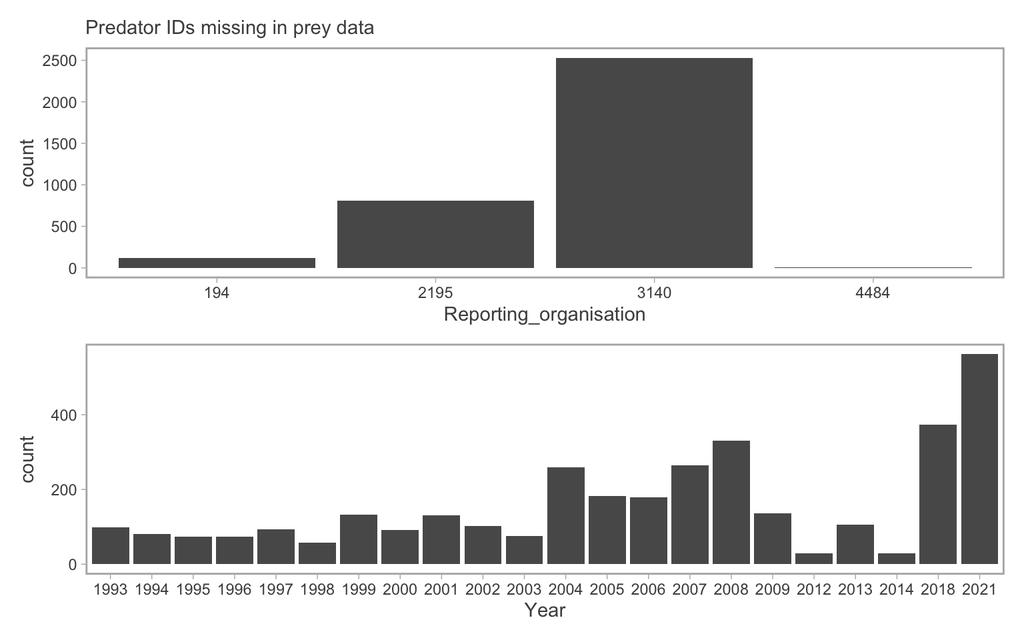

```r
library(patchwork)
p1 / p2
```

```r
pred_not_in_prey |> as.data.frame() |> filter(Year == 2018 & Month == 3 & HaulNo == 1 & Day == 7) |> arrange(FishID) |> distinct(fish_id, .keep_all = TRUE)
```

```
filter: removed 3,451 rows (>99%), 14 rows remaining
```

```
distinct: no rows removed
```

```
   tblUploadID tblHaulID tblPredatorInformationID Ship Gear HaulNo
1         8189      3023                    30549 26D4  TV3      1
2         8189      3023                    30550 26D4  TV3      1
3         8189      3023                    30551 26D4  TV3      1
4         8189      3023                    30552 26D4  TV3      1
5         8189      3023                    30553 26D4  TV3      1
6         8189      3023                    30554 26D4  TV3      1
7         8189      3023                    30555 26D4  TV3      1
8         8189      3023                    29658 26D4  TV3      1
9         8189      3023                    29659 26D4  TV3      1
10        8189      3023                    29660 26D4  TV3      1
11        8189      3023                    29661 26D4  TV3      1
12        8189      3023                    29662 26D4  TV3      1
13        8189      3023                    29663 26D4  TV3      1
14        8189      3023                    29664 26D4  TV3      1
```

[output cut: 90 more lines]

```r
length(unique(pred_not_in_prey$tblPredatorInformationID))
```

```
[1] 3465
```

```r
unique(pred_not_in_prey$tblPredatorInformationID)
```

```
   [1] 15894 15919 15924 15925 15927 15931 15938 15943 15951 15972 15973 16002
  [13] 16004 16007 16013 16015 16016 16019 16096 16098 16103 16118 16125 16128
  [25] 16129 16130 16131 16133 16134 16137 16144 16145 16147 16153 16159 16160
  [37] 16164 16167 16168 16169 16170 16174 16179 16181 16182 16199 16200 16202
  [49] 16206 16211 16212 16213 16214 16215 16229 16230 16234 16244 16246 16249
  [61] 16252 16254 16257 16258 16259 16262 16263 16270 16275 16276 16283 16296
  [73] 16300 16302 16304 16324 16331 16339 16362 16371 16378 16381 16395 16402
  [85] 16428 16429 16438 16442 16443 16448 16451 16452 16454 16456 16461 16462
  [97] 16466 16468 16470 16472 16496 16497 16505 16506 16507 16508 16509 16512
 [109] 16515 16516 16517 16520 16521 16543 16547 16564 16582 16585 16589 16590
 [121] 16603 16771 16779 28290 28293 28297 28298 28299 28300 28301 28303 28304
 [133] 28305 28307 28314 28315 28318 28319 28320 28324 28333 28336 28340 28345
 [145] 28347 28349 28356 28357 28360 28364 28365 28368 28376 28377 28378 28380
 [157] 28383 28384 28385 28387 28389 28393 28395 28396 28399 28401 28407 28411
 [169] 28412 28424 28426 28429 28430 28432 28433 28435 28437 28438 28444 28445
```

[output cut: 274 more lines]

```r
unique(pred_not_in_prey$tblUploadID)
```

```
 [1] 8175 8177 8184 8185 8186 8187 8188 8189 8191 8194 8210 8211 8212 8213 8214
[16] 8215 8216 8217 8218 8219 8220 8221 8222 8223 8224
```

```r
unique(pred_not_in_prey$Reporting_organisation)
```

```
[1]  194 4484 3140 2195
```

```r
# 3140  Institute of Food Safety, Animal Health and Environment (BIOR)  EDMO    False   2015-02-06  2022-08-30
# 194   National Marine Fisheries Research Institute (NMFRI)    EDMO    False   2015-02-06  2021-12-22
# 2195 DTU Aqua, National Institute of Aquatic Resources, Technical University of Denmark
# 4484  Swedish University of Agricultural Sciences, Department of Aquatic Resources (SLU)  EDMO    False   2016-02-11  2022-11-12
```

## Inspect data

Check to see how many predators I have by country and year, to see how much is missing. Because we can’t match them perfectly, I will drop rows that couldn’t be matched in the predator data, using the predator-specific `pred_length` column

```r
# By year and country from years => 1993
d |>
  drop_na(pred_length) |>
  distinct(tblPredatorInformationID, .keep_all = TRUE) |>
  group_by(Country, Year) |>
  summarise(n = n()) |>
  arrange(Year, Country)
```

```
drop_na: no rows removed
```

```
distinct: removed 11,969 rows (53%), 10,601 rows remaining
```

```
group_by: 2 grouping variables (Country, Year)
```

```
summarise: now 24 rows and 3 columns, one group variable remaining (Country)
```

```
# A tibble: 24 × 3
# Groups:   Country [4]
   Country  Year     n
   <chr>   <dbl> <int>
 1 LV       1993   213
 2 LV       1994   143
 3 LV       1995   232
 4 LV       1996   222
 5 LV       1997   135
 6 LV       1998   149
 7 LV       1999   572
 8 LV       2000   447
 9 LV       2001   431
10 LV       2002   390
# ℹ 14 more rows
```

```r
# By year and country from years => 2017
d |>
  drop_na(pred_length) |>
  distinct(tblPredatorInformationID, .keep_all = TRUE) |>
  filter(Year > 2017) |>
  group_by(Country, Year) |>
  summarise(n = n()) |>
  arrange(Year, Country)
```

```
drop_na: no rows removed
```

```
distinct: removed 11,969 rows (53%), 10,601 rows remaining
```

```
filter: removed 8,390 rows (79%), 2,211 rows remaining
```

```
group_by: 2 grouping variables (Country, Year)
```

```
summarise: now 4 rows and 3 columns, one group variable remaining (Country)
```

```
# A tibble: 4 × 3
# Groups:   Country [3]
  Country  Year     n
  <chr>   <dbl> <int>
1 DK       2018   528
2 DK       2021   480
3 PL       2021   582
4 SE       2021   621
```

```r
# Total sample size from years => 1993
d |>
  drop_na(pred_length) |>
  distinct(tblPredatorInformationID, .keep_all = TRUE) |>
  summarise(n = n())
```

```
drop_na: no rows removed
```

```
distinct: removed 11,969 rows (53%), 10,601 rows remaining
```

```
summarise: now one row and one column, ungrouped
```

```
# A tibble: 1 × 1
      n
  <int>
1 10601
```

```r
# Total sample size from years => 2017
d |>
  drop_na(pred_length) |>
  distinct(tblPredatorInformationID, .keep_all = TRUE) |>
  filter(Year > 2017) |>
  summarise(n = n())
```

```
drop_na: no rows removed
```

```
distinct: removed 11,969 rows (53%), 10,601 rows remaining
```

```
filter: removed 8,390 rows (79%), 2,211 rows remaining
```

```
summarise: now one row and one column, ungrouped
```

```
# A tibble: 1 × 1
      n
  <int>
1  2211
```

[We are supposed to have 6128 samples from 2017 and onwards, according to Table A3 in the interim report. We have 2211, which is only 36% of the promised new data.

Now let’s have a look at stomach contents.

## Calculating total weight of specific prey species by unique predator ID

Because of the mismatch in predator ID’s, we will filter the combined dataframe to only have the IDs that are present in both dataframes

```r
pred <- pred |> filter(tblPredatorInformationID %in% unique(prey$tblPredatorInformationID)) # this removes predators not in the prey data
```

```
filter: removed 3,465 rows (25%), 10,601 rows remaining
```

Next we need to summarize our prey weights by predator and prey group. First filter stomachs where these prey are present. Create a new common name column to make life easier…

```r
selected_prey_present <- d |>
  mutate(common_prey_name = NA,
         common_prey_name = ifelse(AphiaIDPrey == 126425, "sprat", common_prey_name),
         common_prey_name = ifelse(AphiaIDPrey == 126417, "herring", common_prey_name),
         common_prey_name = ifelse(AphiaIDPrey == 119034, "saduria", common_prey_name)) |>
  filter(common_prey_name %in% c("sprat", "herring", "saduria"))
```

Check how many predators have these prey in stomachs

```r
length(unique(selected_prey_present$tblPredatorInformationID))
```

```
[1] 5095
```

```r
length(unique(d$tblPredatorInformationID))
```

```
[1] 10601
```

```r
length(unique(selected_prey_present$tblPredatorInformationID)) / length(unique(d$tblPredatorInformationID))
```

```
[1] 0.480615
```

```r
# Now do recent data
length(unique(filter(selected_prey_present, Year > 2016)$tblPredatorInformationID))
```

```
[1] 809
```

```r
length(unique(filter(d, Year > 2016)$tblPredatorInformationID))
```

```
[1] 2211
```

```r
length(unique(filter(selected_prey_present, Year > 2016)$tblPredatorInformationID)) / length(unique(filter(d, Year > 2016)$tblPredatorInformationID))
```

```
[1] 0.3658978
```

Only 48% of cod have *any* of these prey species? That sounds fairly low, given that these are the most common prey and likely make up >80% of a cod’s diet around 30 cm. Update! This percentage is higher now that I have old data as well. In the newer data this number is around 36%

Next we want to group be predator and prey, and summarize the total weight. Before though, we need to make sure there are no `NA`s in `Weight`

```r
unique(selected_prey_present$Weight)
```

```
 [1]   5   1   2   6  12  10   0   4   8   3   7  25  11  20   9  27  15  34  18
[20]  21  26  17  14  13  23  22  42  30  50  31  47  16  37  55  33  NA  24  19
[39]  58  28  41  80  32  29  66  89  36 122  88  67 165  72  43  35  40  76  48
[58]  57  52  83  38  44  79 327 190  51  69  54 189 142 102  49  45  60  99  70
[77]  53  61  73  39 132  63 893  87  92  65  62  46  74  68 216 324 156  56 115
```

```r
selected_prey_present <- selected_prey_present |> drop_na(Weight)
```

```
drop_na: removed 111 rows (1%), 8,973 rows remaining
```

There are also weights that are 0 (21%!). How can a prey weigh nothing? If it can’t be measured I would have assumed it to be NA. Here are the analyzing organisations and the predator ID’s.

```r
zero_weights <- selected_prey_present |> filter(!Weight == 0)
```

```
filter: removed 1,856 rows (21%), 7,117 rows remaining
```

```r
unique(zero_weights$AnalysingOrg)
```

```
[1]  194 3140 2195
```

```r
unique(zero_weights$tblPredatorInformationID)
```

```
   [1] 15895 15898 15902 15904 15905 15908 15958 15961 15992 15987 15984 15975
  [13] 15981 15978 15979 15966 15954 15962 15949 15930 15928 15947 15929 15941
  [25] 15913 15933 15932 15942 15945 15971 15977 15937 15921 15915 15993 15989
  [37] 15967 15968 15990 15991 15985 15983 15969 15986 15964 15960 15970 15974
  [49] 15976 15955 15956 15946 15944 15934 16005 16010 16014 16012 16020 16017
  [61] 16031 16119 16124 16218 16188 16184 16155 16178 16196 16204 16210 16224
  [73] 16225 16201 16136 16222 16185 16193 16217 16197 16186 16216 16177 16172
  [85] 16165 16219 16223 16161 16173 16189 16163 16142 16175 16157 16180 16150
  [97] 16171 16187 16141 16192 16166 16139 16148 16146 16156 16149 16236 16238
 [109] 16237 16241 16240 16239 16253 16260 16269 16264 16267 16268 16274 16273
 [121] 16272 16277 16288 16290 16292 16293 16295 16297 16299 16333 16336 16338
 [133] 16341 16368 16398 16399 16400 16401 16403 16408 16409 16427 16431 16433
 [145] 16440 16457 16458 16463 16467 16471 16489 16493 16498 16499 16500 16504
 [157] 16510 16511 16514 16518 16524 16528 16539 16542 16545 16556 16561 16576
 [169] 16583 16584 16588 16594 16602 16606 16608 16610 16611 16612 16613 16651
```

[output cut: 309 more lines]

```r
# 3140  Institute of Food Safety, Animal Health and Environment (BIOR)  EDMO    False   2015-02-06  2022-08-30
# 194   National Marine Fisheries Research Institute (NMFRI)    EDMO    False   2015-02-06  2021-12-22
# 2195 DTU Aqua, National Institute of Aquatic Resources, Technical University of Denmark
```

21% of rows where these prey are present do not have a weight…. Do they have a length? Can we estimate Weight? If length is not `NA` and Weight is 0, estimate weight based on length and multiply with the count of prey. Else give weight `NA` and drop it.

```r
t <- selected_prey_present |>
  mutate(weight_source = ifelse(Weight == 0 & !is.na(prey_length) & !is.na(Count), "estimated", "observed")) |>
  mutate(Weight = ifelse(weight_source == "estimated", (0.01*prey_length^3)*Count, Weight)) |>
  filter(Weight > 0)
```

```
mutate: new variable 'weight_source' (character) with 2 unique values and 0% NA
```

```
mutate: changed 451 values (5%) of 'Weight' (0 new NA)
```

```
filter: removed 1,413 rows (16%), 7,560 rows remaining
```

Even if we estimate the prey weight based on the length of the prey and the number of the prey, we still have 16% of rows in this data with saduria, herring and sprat that does not have any weight information, even though they were clearly present in the data. We can see that here:

```r
selected_prey_present |>
  filter(Weight == 0) |>
  head(5)
```

```
filter: removed 7,117 rows (79%), 1,856 rows remaining
```

```
# A tibble: 5 × 60
  tblUploadID tblHaulID tblPredatorInformatio…¹ tblPreyInformationID Ship  Gear
        <dbl>     <dbl>                   <dbl>                <dbl> <chr> <chr>
1        8175      2596                   15908                21462 67BC  TVL
2        8175      2597                   15979                21502 67BC  TVL
3        8175      2597                   15966                21505 67BC  TVL
4        8175      2597                   15911                21551 67BC  TVL
5        8175      2597                   15926                21554 67BC  TVL
# ℹ abbreviated name: ¹tblPredatorInformationID
# ℹ 54 more variables: HaulNo <dbl>, StationNumber <dbl>, Year <dbl>,
#   Month <dbl>, Day <dbl>, Time <chr>, FishID <dbl>, AphiaIDPredator <dbl>,
#   AphiaIDPrey <dbl>, IdentMet <chr>, DigestionStage <dbl>, GravMethod <chr>,
#   SubFactor <dbl>, PreySequence <dbl>, Count <dbl>, UnitWgt <chr>,
#   Weight <dbl>, UnitLngt <chr>, prey_length <dbl>, OtherItems <chr>,
#   OtherCount <dbl>, OtherWgt <dbl>, AnalysingOrg <dbl>, prey_notes <chr>, …
```

I *guess* this is because they couldn’t be measured or weighed, only counted. Which seems fair. For our purpose, it would probably be less wrong to give them the average weight rather than treating them as 0s, so that’s what I’ll do here.

```r
prey_avg_ind_weight <- selected_prey_present |>
  filter(!is.na(Count) & Weight > 0 & Count > 0) |> # -999 count here...
  group_by(common_prey_name) |>
  mutate(ind_weight = Weight / Count) |>
  summarise(avg_weight = mean(ind_weight))
```

```
filter: removed 2,954 rows (33%), 6,019 rows remaining
```

```
group_by: one grouping variable (common_prey_name)
```

```
mutate (grouped): new variable 'ind_weight' (double) with 224 unique values and 0% NA
```

```
summarise: now 3 rows and 2 columns, ungrouped
```

```r
prey_avg_ind_weight
```

```
# A tibble: 3 × 2
  common_prey_name avg_weight
  <chr>                 <dbl>
1 herring               21.9
2 saduria                3.47
3 sprat                  6.73
```

This should be the average prey weight which we can use to calculate the weight of these prey if we have the counts. Left join to data.

```r
selected_prey_present_clean <- selected_prey_present |>
  left_join(prey_avg_ind_weight) |>
  mutate(weight_source = ifelse(Weight == 0 & !is.na(prey_length) & !is.na(Count), "estimated", "observed")) |>
  mutate(Weight = ifelse(weight_source == "estimated", (0.01*prey_length^3)*Count, Weight)) |>
  group_by(common_prey_name) |>
  mutate(Weight = ifelse(Weight == 0 & !is.na(Count), Count * avg_weight, Weight)) |>
  filter(Weight > 0)
```

```
left_join: added one column (avg_weight)
> rows only in x 0
> rows only in y ( 0)
> matched rows 8,973
> =======
> rows total 8,973
mutate: new variable 'weight_source' (character) with 2 unique values and 0% NA
mutate: changed 451 values (5%) of 'Weight' (0 new NA)
group_by: one grouping variable (common_prey_name)
mutate (grouped): changed 857 values (10%) of 'Weight' (0 new NA)
filter (grouped): removed 556 rows (6%), 8,417 rows remaining
```

With these estimates of weight based on either length or worst case, average weight of that prey, we need to drop 556 rows in the presence data (around 6%). Now calculate the total weight of these prey per individual predator stomach, and then pivot wider.

```r
selected_prey_present_summed <- selected_prey_present_clean |>
  group_by(tblPredatorInformationID, common_prey_name) |>
  summarise(tot_weight = sum(Weight)) |>
  ungroup()
```

```
group_by: 2 grouping variables (tblPredatorInformationID, common_prey_name)
```

```
summarise: now 5,367 rows and 3 columns, one group variable remaining (tblPredatorInformationID)
```

```
ungroup: no grouping variables
```